# Milestone report - Data Science Capstone

28 december 2020

## Executive summary

This milestone report is written for the Coursera Johns Hopkins Data Science Specialization capstone project.

The Capstone Project involves developing a predictive model of text starting with a really large, unstructured database of the English language.This report display the progress on the development of the predictive model. It contains the following sections: 1. Load and prepare data 2. Summary statistics on the text datasets 3. Further steps in building the model

## Analysis description

Around the world, people are spending an increasing amount of time on their mobile devices for email, social networking, banking and a whole range of other activities. But typing on mobile devices can be a serious pain. SwiftKey, our corporate partner in this capstone, builds a smart keyboard that makes it easier for people to type on their mobile devices. One cornerstone of their smart keyboard is predictive text models. When someone types:

I went to the

the keyboard presents three options for what the next word might be. For example, the three words might be gym, store, restaurant.

This reports show the underlying datasources and progress of the development of the predictive model.

## Module 1: Settings

```r
print('Settings fully loaded')
```

```
## [1] "Settings fully loaded"
```

# Module 2: Load and prepare data and determine subsample

In this module, the text data is loaded and analyzed for generating descriptive statistics on the available data.As the data is very large, a subsample of the data is generated from the 3 different input files. Next to the source text fieles, additional files are loaded such as a file with profanity language to extract this from the source data. In the data cleaning stage the profanity language is removed and a standard format of the words (e.g. lower, no leading/trailing white spaces) is determined.

```r
# Create empty stats dataframe
stats_list <- list()

# Loop through filenames to derive text data
for (text_filename in text_filenames){

        # Determine paths
        load_text_path <- paste(curr_dir, language, text_filename, sep = '/')
        save_text_path <- paste(curr_dir, language, paste0('sample_', text_filename), sep = '/')

        # Read text data and derive summary statistics
        text_data <- readLines(load_text_path, encoding = "UTF-8", skipNul=TRUE)

        # Get file size
        file_size <- round((file.info(load_text_path)$size / 1024 ^ 2),2)
        # Number of lines
        n_lines <- length(text_data)
        # Number words in file
        n_words <- sum(sapply(gregexpr("\\S+", text_data), length))
        # Collect stats in array and append to dataframe
        text_stats <- c(text_filename, file_size, n_lines, n_words)
        stats_list[[text_filename]] <- text_stats

        # Check if sample file already exists within directory
        directory_files <- list.files(paste(curr_dir, language, sep = '/'))
        sample_existence_flag <- ifelse(length(directory_files[grepl(paste0('sample_', text_filename),
                                                               directory_files, fixed = TRUE)]) > 0, TRUE, FALSE)

        # If sample file does not exist create and save
        if(sample_existence_flag == FALSE){

                # Read a subsample of lines from the core datasource
                sample_text_data <- sample_lines(load_text_path, (length(load_text_path)/100)*1) # this give 1% of lines

                # Save sample text data
                write.table(sample_text_data, file = save_text_path, row.names = FALSE, sep = ';')
                print(paste('Sample file saved', text_filename, sep = ' '))
                } else {
                        paste('Sample file not saved', text_filename, sep = ' ')
                }
}

# Set column names of stats df
stats_df <- data.frame(do.call("rbind",stats_list))
colnames(stats_df) <- c("file_name", "file_size_mb", "n_lines", 'n_words')

# Display file statistics
stats_df
```

```
##                           file_name file_size_mb n_lines  n_words
## en_US.twitter.txt en_US.twitter.txt       159.36 2360148 30373583
## en_US.blogs.txt     en_US.blogs.txt       200.42  899288 37334131
## en_US.news.txt       en_US.news.txt       196.28   77259  2643969
```

```r
# Load subsample text data

text_list <- c()

for (text_filename in text_filenames){

        # Determine path
        save_text_path <- paste(curr_dir, language, paste0('sample_', text_filename), sep = '/')

        # Load data
        text_data <- readLines(save_text_path, encoding="UTF-8")

        # Append lines of single doc to the text list
        text_list <- append(text_list, text_data)
}

# Define training data
training_data <- text_list

# Load NLP support files

  # Determine paths
NLP_support_path <- paste(curr_dir, 'NLP support', 'bad-words.txt', sep = '/')

  # Read file
bad_words_data <- readLines(NLP_support_path)
```

```r
# Create a corpus
docs <- VCorpus(VectorSource(training_data))

# # Eliminate extra white spaces
docs <- tm_map(docs, stripWhitespace)
# Convert the text to lower case
docs <- tm_map(docs, content_transformer(tolower))
# Remove numbers
docs <- tm_map(docs, removeNumbers)
# Remove profanity language
docs <- tm_map(docs, removeWords, bad_words_data)
# Remove punctuations
docs <- tm_map(docs, removePunctuation)
# Eliminate extra white spaces
docs <- tm_map(docs, stripWhitespace)
# Remove non ascii characters
docs <- tm_map(docs, content_transformer(function(x) iconv(x, "latin1", "ASCII", sub="")))
```

# Module 3: Data Descriptives

In this module, the corpus is used to create a term document matrix of ngrams (1, 2, 3, 4 & 5), which is used to calculate ngram frequency in the corpus and create descriptive insights on the data which is used for modelling.

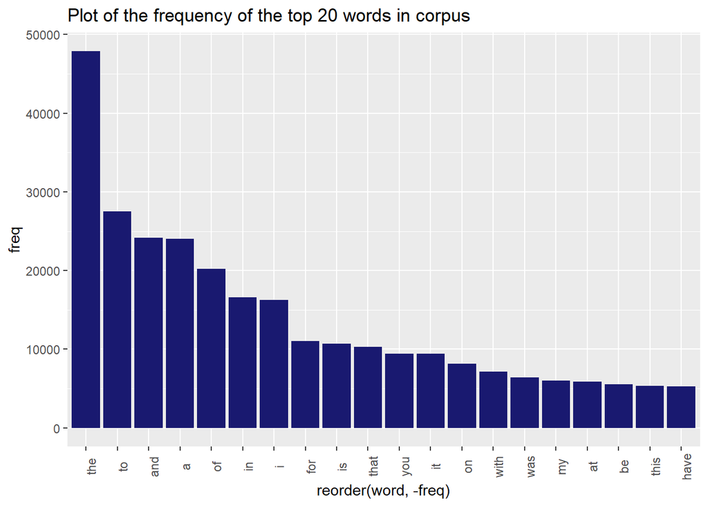

```r
# Create unigram token function
ngram_tokenizer <- function(x) {
  unlist(lapply(ngrams(words(x), 1), paste, collapse = " "), use.names = FALSE)
}

# Get frequency of words
tdm_unigram <- TermDocumentMatrix(docs, control=list(wordLengths=c(1,Inf)))

# Create dataframe
freq_unigram <- sort(row_sums(tdm_unigram), decreasing = TRUE)
freq_unigram_df <- data.frame(word=names(freq_unigram ), freq=freq_unigram)

# Remove if ngram only occurs once
freq_unigram_df <- freq_unigram_df[freq_unigram_df$freq > 1, ]

# # Plot top 20 words

freq_unigram_df_top_20 <- head(freq_unigram_df, 20)
ggplot(freq_unigram_df_top_20, aes(x = reorder(word, -freq), y = freq)) +
  ggtitle("Plot of the frequency of the top 20 words in corpus") +
  geom_bar(stat = "identity", fill = "#191970") +
  theme(axis.text.x = element_text(angle = 90))
```

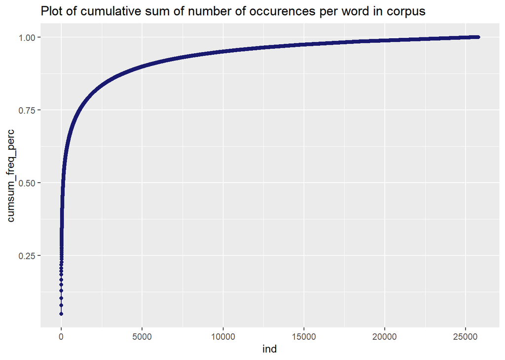

```r
# Add cumulative sum to dataframe
freq_unigram_df$cumsum_freq_perc <- cumsum(freq_unigram_df$freq) / sum(freq_unigram_df$freq)
freq_unigram_df$ind <- seq.int(nrow(freq_unigram_df))

# Plot cumulative sum of number of occurences per word
ggplot(data = freq_unigram_df, aes(x = ind, y = cumsum_freq_perc, group=1)) +
  ggtitle("Plot of cumulative sum of number of occurences per word in corpus") +
  geom_line(colour = "#191970") +
  geom_point(colour = "#191970") +
  scale_x_continuous(breaks = scales::pretty_breaks(n = 10))
```

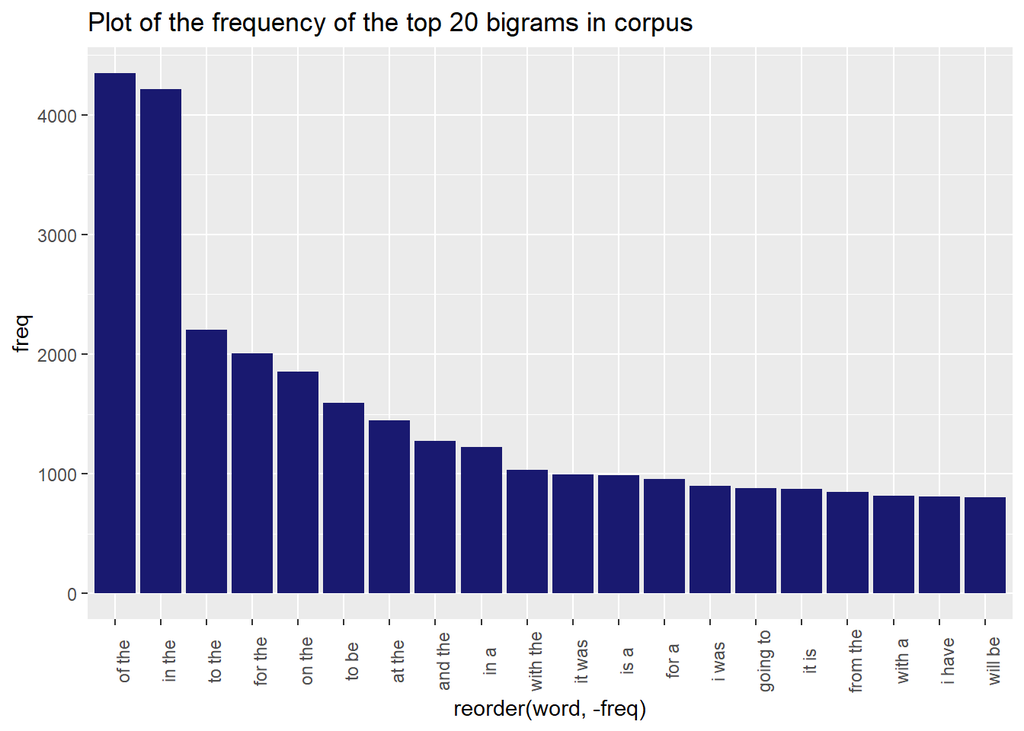

```r
# Create ngram token function
ngram_tokenizer <- function(x) {
  unlist(lapply(ngrams(words(x), 2), paste, collapse = " "), use.names = FALSE)
}

# Get frequency of ngrams
tdm_bigram = TermDocumentMatrix(docs, control = list(tokenize = ngram_tokenizer))

# Create dataframe
freq_bigram = sort(row_sums(tdm_bigram), decreasing = TRUE)
freq_bigram_df = data.frame(word = names(freq_bigram), freq = freq_bigram)

# Remove if ngram only occurs once
freq_bigram_df <- freq_bigram_df[freq_bigram_df$freq > 1, ]

# Plot top 20 words
freq_bigram_df_top_20 <- head(freq_bigram_df, 20)
ggplot(freq_bigram_df_top_20, aes(x = reorder(word, -freq), y = freq)) +
  ggtitle("Plot of the frequency of the top 20 bigrams in corpus") +
  geom_bar(stat = "identity", fill = "#191970") +
  theme(axis.text.x = element_text(angle = 90))
```

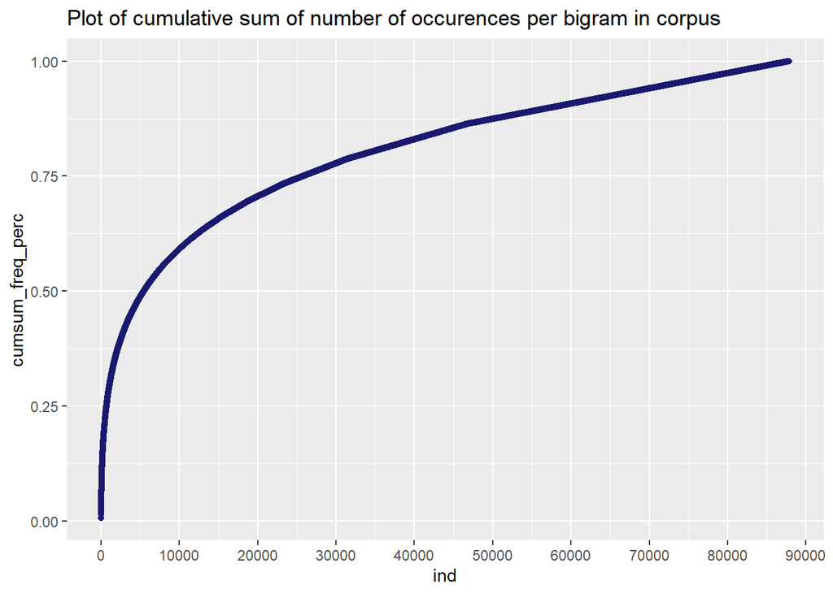

```r
# Add cumulative sum to dataframe
freq_bigram_df $cumsum_freq_perc <- cumsum(freq_bigram_df $freq) / sum(freq_bigram_df$freq)
freq_bigram_df$ind <- seq.int(nrow(freq_bigram_df))

# Plot cumulative sum of number of occurences per word
ggplot(data = freq_bigram_df , aes(x = ind, y = cumsum_freq_perc, group=1)) +
  ggtitle("Plot of cumulative sum of number of occurences per bigram in corpus") +
  geom_line(colour = "#191970") +
  geom_point(colour = "#191970") +
  scale_x_continuous(breaks = scales::pretty_breaks(n = 10))
```

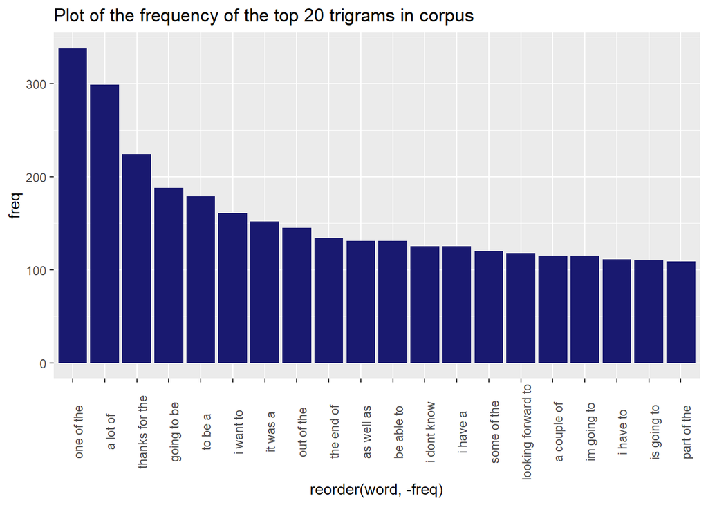

```r
# Create ngram token function
ngram_tokenizer <- function(x) {
  unlist(lapply(ngrams(words(x), 3), paste, collapse = " "), use.names = FALSE)
}

# Get frequency of ngrams
tdm_trigram = TermDocumentMatrix(docs, control = list(tokenize = ngram_tokenizer))

# Create dataframe
freq_trigram =  sort(row_sums(tdm_trigram), decreasing = TRUE)
freq_trigram_df = data.frame(word = names(freq_trigram), freq = freq_trigram)

# Remove if ngram only occurs once
freq_trigram_df <- freq_trigram_df[freq_trigram_df$freq > 1, ]

# Plot top 20 words
freq_trigram_df_top_20 <- head(freq_trigram_df, 20)
ggplot(freq_trigram_df_top_20, aes(x = reorder(word, -freq), y = freq)) +
  ggtitle("Plot of the frequency of the top 20 trigrams in corpus") +
  geom_bar(stat = "identity", fill = "#191970") +
  theme(axis.text.x = element_text(angle = 90))
```

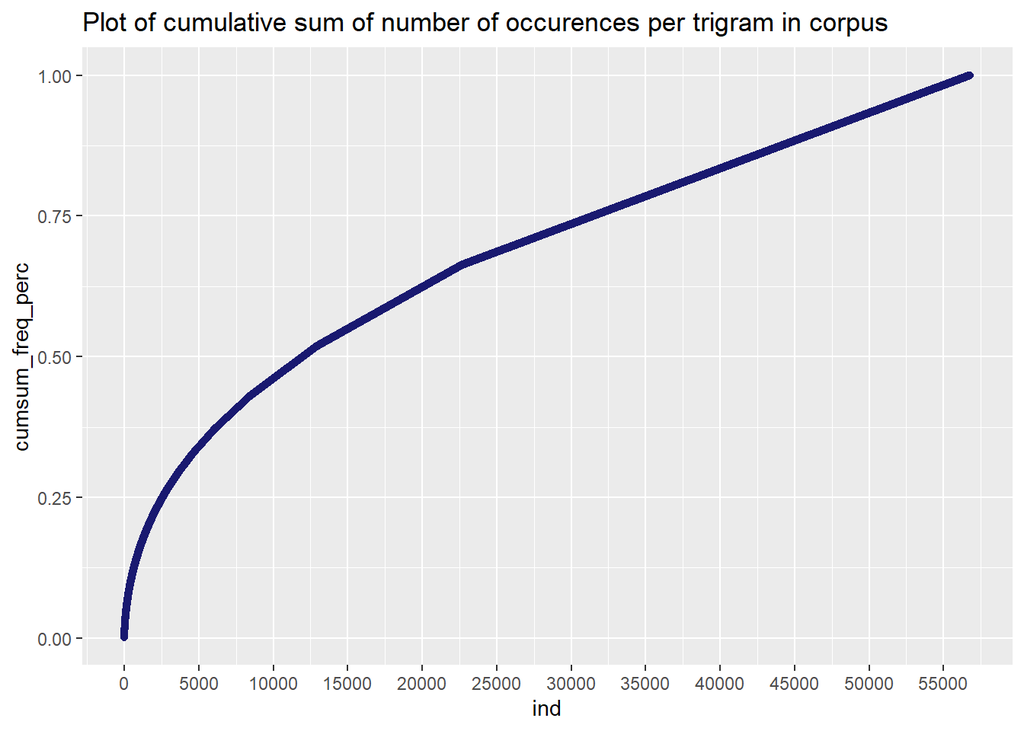

```r
# Add cumulative sum to dataframe
freq_trigram_df$cumsum_freq_perc <- cumsum(freq_trigram_df$freq) / sum(freq_trigram_df$freq)
freq_trigram_df$ind <- seq.int(nrow(freq_trigram_df))

# Plot cumulative sum of number of occurences per word
ggplot(data = freq_trigram_df, aes(x = ind, y = cumsum_freq_perc, group=1)) +
  ggtitle("Plot of cumulative sum of number of occurences per trigram in corpus") +
  geom_line(colour = "#191970") +
  geom_point(colour = "#191970") +
  scale_x_continuous(breaks = scales::pretty_breaks(n = 10))
```

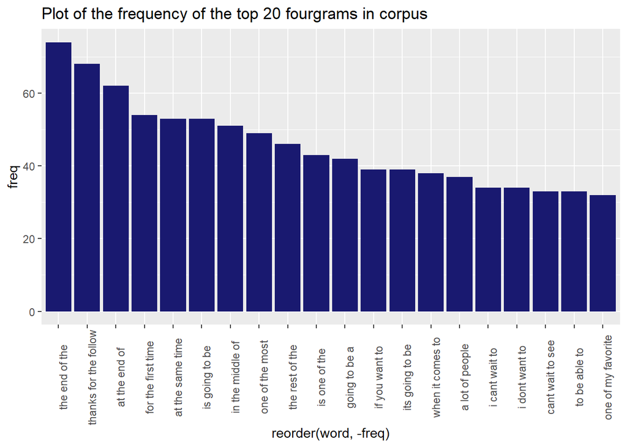

```r
# Create ngram token function
ngram_tokenizer <- function(x) {
  unlist(lapply(ngrams(words(x), 4), paste, collapse = " "), use.names = FALSE)
}

# Get frequency of ngrams
tdm_fourgram = TermDocumentMatrix(docs, control = list(tokenize = ngram_tokenizer))

# Create dataframe
freq_fourgram_df =  sort(row_sums(tdm_fourgram), decreasing = TRUE)
freq_fourgram_df = data.frame(word = names(freq_fourgram_df), freq = freq_fourgram_df)

# Remove if ngram only occurs once
freq_fourgram_df <- freq_fourgram_df[freq_fourgram_df$freq > 1, ]

# Plot top 20 words
freq_fourgram_df_top_20 <- head(freq_fourgram_df, 20)
ggplot(freq_fourgram_df_top_20, aes(x = reorder(word, -freq), y = freq)) +
  ggtitle("Plot of the frequency of the top 20 fourgrams in corpus") +
  geom_bar(stat = "identity", fill = "#191970") +
  theme(axis.text.x = element_text(angle = 90))
```

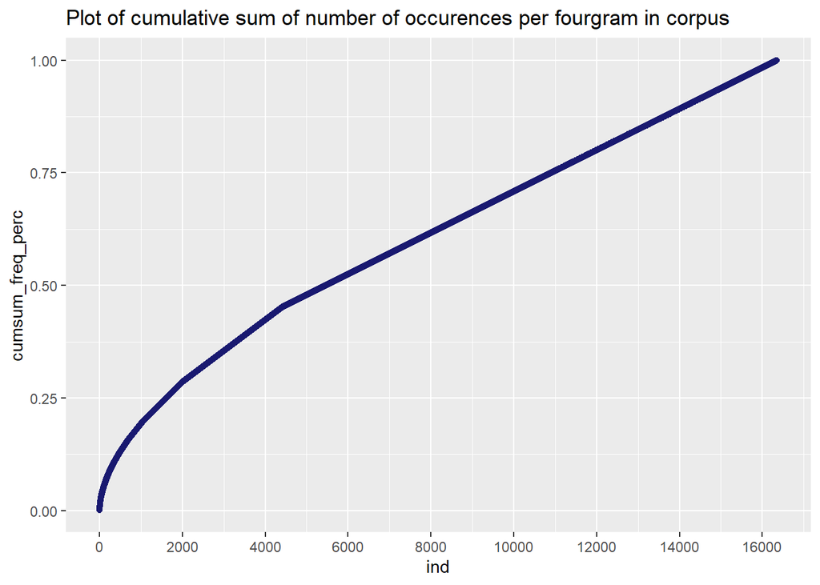

```r
# Add cumulative sum to dataframe
freq_fourgram_df$cumsum_freq_perc <- cumsum(freq_fourgram_df$freq) / sum(freq_fourgram_df$freq)
freq_fourgram_df$ind <- seq.int(nrow(freq_fourgram_df))

# Plot cumulative sum of number of occurences per word
ggplot(data = freq_fourgram_df, aes(x = ind, y = cumsum_freq_perc, group=1)) +
  ggtitle("Plot of cumulative sum of number of occurences per fourgram in corpus") +
  geom_line(colour = "#191970") +
  geom_point(colour = "#191970") +
  scale_x_continuous(breaks = scales::pretty_breaks(n = 10))
```

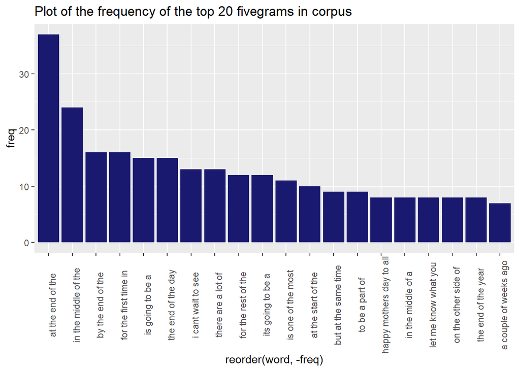

```r
# Create ngram token function
ngram_tokenizer <- function(x) {
  unlist(lapply(ngrams(words(x), 5), paste, collapse = " "), use.names = FALSE)
}

# Get frequency of ngrams
tdm_fivegram = TermDocumentMatrix(docs, control = list(tokenize = ngram_tokenizer))

# Create dataframe
freq_fivegram_df =  sort(row_sums(tdm_fivegram), decreasing = TRUE)
freq_fivegram_df = data.frame(word = names(freq_fivegram_df), freq = freq_fivegram_df)

# Remove if ngram only occurs once
freq_fivegram_df <- freq_fivegram_df[freq_fivegram_df$freq > 1, ]

# Plot top 20 words
freq_fivegram_df_top_20 <- head(freq_fivegram_df, 20)
ggplot(freq_fivegram_df_top_20, aes(x = reorder(word, -freq), y = freq)) +
  ggtitle("Plot of the frequency of the top 20 fivegrams in corpus") +
  geom_bar(stat = "identity", fill = "#191970") +
  theme(axis.text.x = element_text(angle = 90))
```

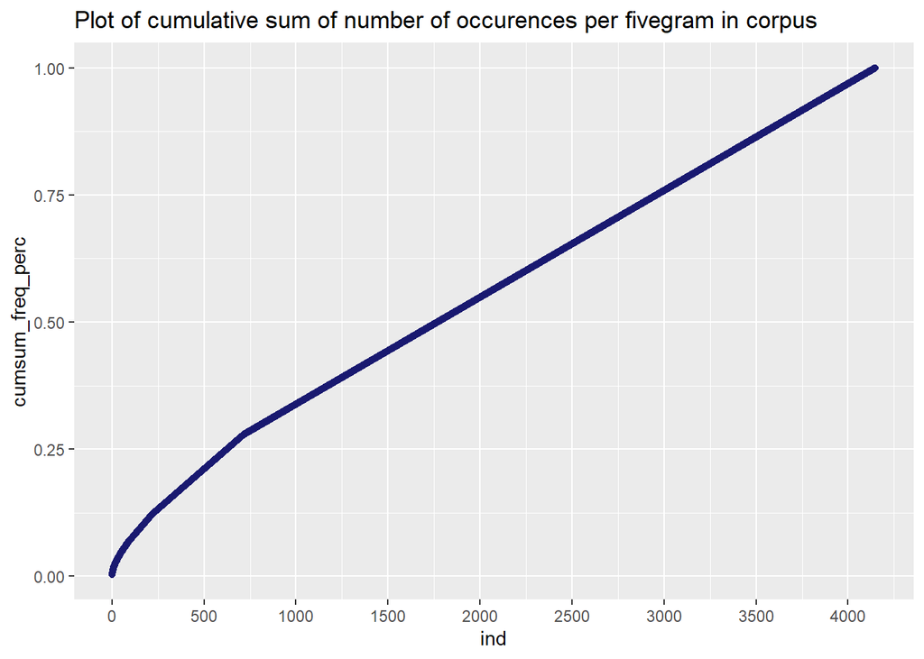

```r
# Add cumulative sum to dataframe
freq_fivegram_df$cumsum_freq_perc <- cumsum(freq_fivegram_df$freq) / sum(freq_fivegram_df$freq)
freq_fivegram_df$ind <- seq.int(nrow(freq_fivegram_df))

# Plot cumulative sum of number of occurences per word
ggplot(data = freq_fivegram_df, aes(x = ind, y = cumsum_freq_perc, group=1)) +
  ggtitle("Plot of cumulative sum of number of occurences per fivegram in corpus") +
  geom_line(colour = "#191970") +
  geom_point(colour = "#191970") +
  scale_x_continuous(breaks = scales::pretty_breaks(n = 10))
```

```r
save(freq_unigram_df, freq_bigram_df, freq_trigram_df,
     freq_fourgram_df, freq_fivegram_df, file="Data/PROCESSED/freq_ngrams.RData")
```

## Module 4: Further steps in building the model

This concludes the exploratory analysis of the datasets which will be used for the predictive model. In the next step, the predictive model will be created and integrated into a Shiny app for word prediction.

The ngram frequency dataframes are used to calculate the probability of the next word occuring. The input string will be tokenized and the words before the last word in the n-gram will be isolated and matched against the frequency data frames to identify the ngram with the higest probability and substract the predictid word from this ngram.

In order to let a user interact with the model, a shiny application will be build. In this application, a user can provided a line of text for which the most likely options of the next word will be provided.